# Data Quality Check Report

Insitute for Alpine Environment, Eurac Research

Report start at **2017-12-12 12:07:17**

### INPUT info:

File selected: **M4s.dat**

You have also select these parameters:

- Data start from row: *5*
- The name of column is on row: *2*
- The datetime header is: *TIMESTAMP*
- The record header is: *RECORD*
- The datetime format is: *yyyy-mm-dd HH:MM*
- The sampling interval is: *15 min*

The folders are:

- Data folder: *H:/Projekte/Klimawandel/Experiment/data/2order/DataQualityCheckEuracAlpEnv//Data/Input/*
- Report folder: *H:/Projekte/Klimawandel/Experiment/data/2order/DataQualityCheckEuracAlpEnv/Report/*
- Output folder: *H:/Projekte/Klimawandel/Experiment/data/2order/DataQualityCheckEuracAlpEnv/Data/Output/*
- Support folder: *H:/Projekte/Klimawandel/Experiment/data/2order/DataQualityCheckEuracAlpEnv/Data/Support_files/*

Range file in support folder is called: *Range.csv*

You decide: *to don’t write output file in output folder*

### OUTPUT:

#### Info empty file:

M4s.dat has some obseravtion.

#### **Overlap**

In M4s.dat there isn’t any overlap!

#### **Missing dates**

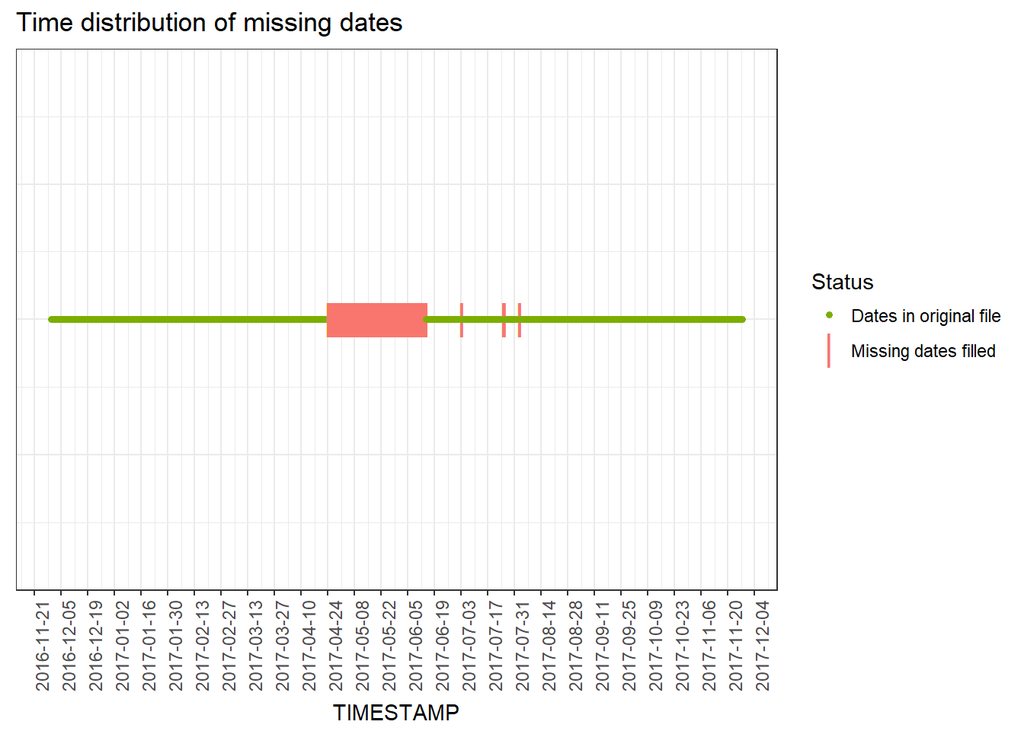

Statistics of missing dates:

| From | To | Number of Record |
| --- | --- | --- |
| 2017-04-24 05:45:00 | 2017-06-14 15:15:00 | 4935 |
| 2017-07-03 08:30:00 | 2017-07-03 08:45:00 | 2 |
| 2017-07-25 13:30:00 | 2017-07-25 14:00:00 | 3 |
| 2017-08-02 14:30:00 | 2017-08-02 15:00:00 | 3 |

#### **Values out of admitted range**

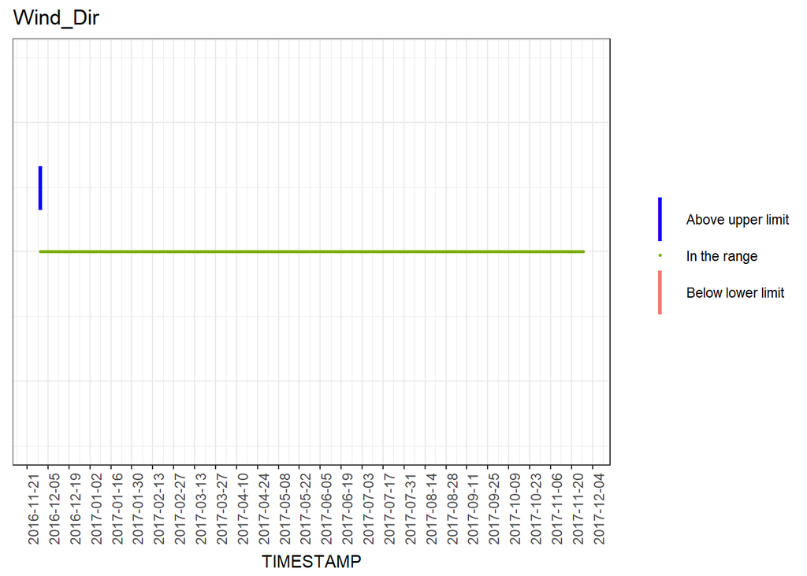

|  | From | To | Number of Record |
| --- | --- | --- | --- |
| Above upper limit | 2016-11-29 15:15:00 | 2016-11-29 15:15:00 | 1 |

Report end at **2017-12-12 12:07:50**